# FALL IE 423 - PROJECT PART 1 CODE & REPORT

## Akbank

Akbank T.A.S. is one of the leading banks in Turkey, offering a wide range of financial services to individuals, commercial enterprises, and corporate clients. With a strong presence in the Turkish banking sector, Akbank is known for its innovative solutions, customer-centric approach, and technological advancements. The bank provides various financial products and services, including retail banking, commercial banking, investment banking, asset management, and more. It has a history of robust performance and has been recognized for its contributions to the Turkish economy.

During the thorough analysis of Akbank's stock price data spanning the period from 2016 to 2018, several monthly outliers are uncovered. In November 2016, 5 instances of higher outliers were identified, all of which were dated 2016-11-01. The specific data points are outlined below:

2016-11-01 06:45:00+00:00 6.6761

2016-11-01 07:15:00+00:00 6.6761

2016-11-01 08:00:00+00:00 6.6761

2016-11-01 11:15:00+00:00 6.6761

2016-11-01 11:30:00+00:00 6.6761

##### Plotted Data

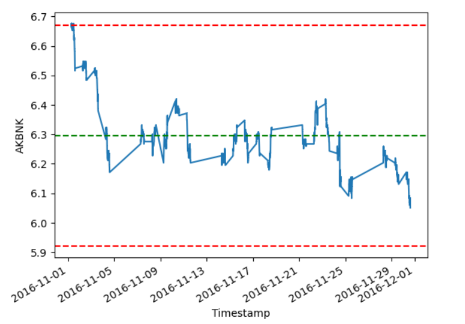

##### Google Trend Data

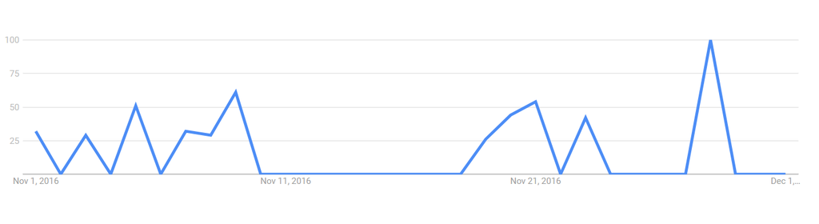

The increase in stock prices for Akbank on November 1, 2016, can be attributed to the positive market response following the announcement of interest rate reductions on housing loans, as well as general-purpose and vehicle loans. Akbank's decision to lower interest rates on various loan products, including housing loans, general-purpose loans, and vehicle loans, is a strategic move that can stimulate demand for these financial products.

By reducing interest rates, Akbank becomes more competitive in the lending market, potentially attracting more borrowers seeking affordable financing options. This proactive approach to adjusting interest rates could lead to an increase in loan uptake, fostering growth in the bank's loan portfolio and, consequently, its overall revenue. A boost in lending activity and positive market sentiment toward the bank's strategic decisions may have influenced investors to perceive Akbank as a more favorable investment option, thereby driving an increase in its stock prices on November 1, 2016.

In January 2017, 3 instances of higher outliers were identified, all of which were dated 2017-01-31. The specific data points are outlined below:

2017-01-31 11:30:00+00:00 6.7643

2017-01-31 14:15:00+00:00 6.7643

2017-01-31 14:30:00+00:00 6.7803

##### Plotted Data

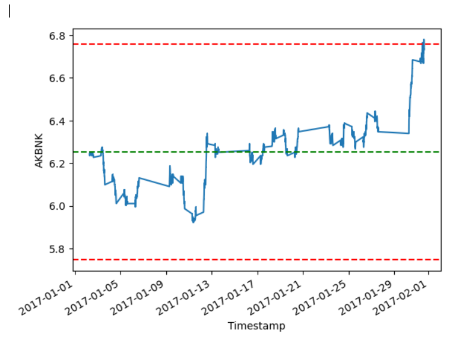

##### Google Trend Data

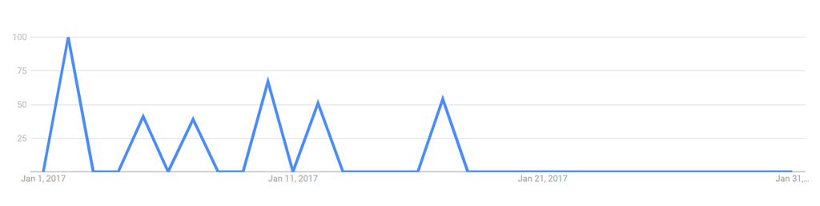

On this date, Foreks released a survey forecasting AKBANK's fourth-quarter net profit for 2016 to be approximately 1 billion 86 million Turkish Lira. According to the survey, the average balance sheet projection was in line with this estimation, with the highest forecast at 1 billion 125 million Turkish Lira and the lowest at 1 billion 52 million Turkish Lira. These positive forecasts from the survey likely had a favorable impact on AKBANK's stock values, as they indicated a potentially robust financial performance, fostering investor confidence and positive market sentiment.

This positive prediction and alignment with the analysts' estimates suggested a stable and potentially strong financial performance for AKBANK during the mentioned period. Such optimistic projections often result in an increase in investor confidence and a positive perception of the company's financial health. As a result, investors may be more inclined to purchase AKBANK stocks, expecting a favorable return on their investment.

In February 2017, 2 instances of lower outliers were identified, all of which were dated 2017-02-01. The specific data points are outlined below:

2017-02-01 08:15:00+00:00 6.6681 2017-02-01 08:30:00+00:00 6.6521

##### Plotted Data

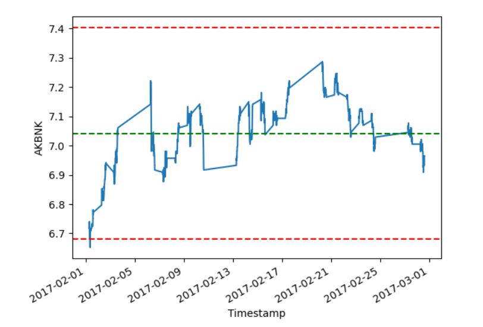

##### Google Trend Data

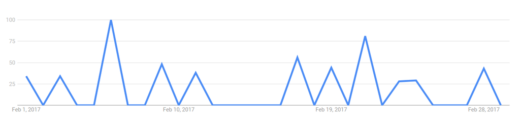

In March 2017, 11 instances of higher outliers were identified, which were dated 2017-03-06 and 2017-03-07. The specific data points are outlined below:

2017-03-06 12:45:00+00:00 7.4375

2017-03-06 13:00:00+00:00 7.4375

2017-03-06 13:15:00+00:00 7.4375

2017-03-06 13:30:00+00:00 7.4375

2017-03-06 13:45:00+00:00 7.4294

2017-03-06 14:00:00+00:00 7.4294

2017-03-07 06:45:00+00:00 7.4535

2017-03-07 07:00:00+00:00 7.4294

2017-03-07 07:15:00+00:00 7.4615

2017-03-07 07:30:00+00:00 7.4375

2017-03-07 07:45:00+00:00 7.4455

##### Plotted Data

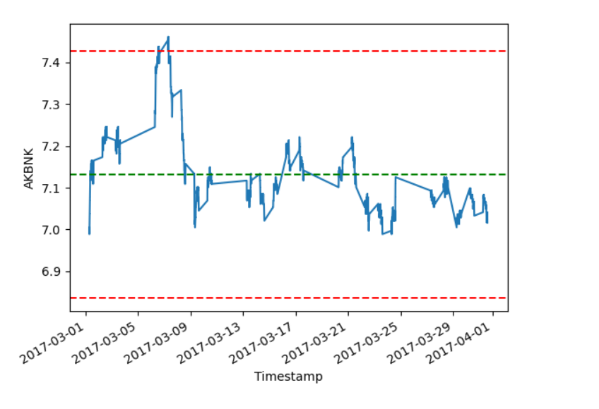

##### Google Trend Data

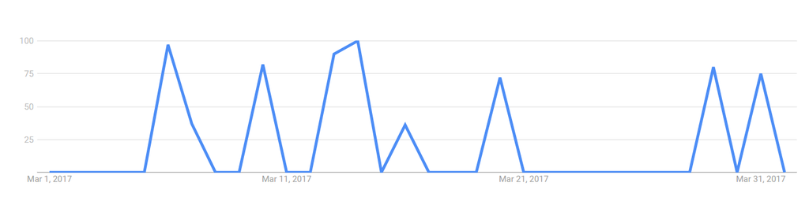

On the relevant dates, Fitch Ratings' publication regarding Akbank's Basel III compliant capital similar US Dollar-denominated bonds could potentially have a positive impact on Akbank's stock prices for several reasons. Firstly, a favorable rating from a well-regarded credit rating agency like Fitch can bolster investor confidence in the bank's financial stability and creditworthiness. This increased confidence can attract more investors to purchase Akbank's stocks, generating heightened demand and the possibility of an upward trajectory in stock prices.

In October 2017, 9 instances of lower outliers were identified, which were dated 2017-10-09. The specific data points are outlined below:

2017-10-09 07:00:00+00:00 7.3946

2017-10-09 07:30:00+00:00 7.4357

2017-10-09 07:45:00+00:00 7.4439

2017-10-09 08:00:00+00:00 7.4357

2017-10-09 08:15:00+00:00 7.4192

2017-10-09 08:30:00+00:00 7.4275

2017-10-09 08:45:00+00:00 7.4192

2017-10-09 09:00:00+00:00 7.4275

2017-10-09 09:15:00+00:00 7.4357

##### Plotted Data

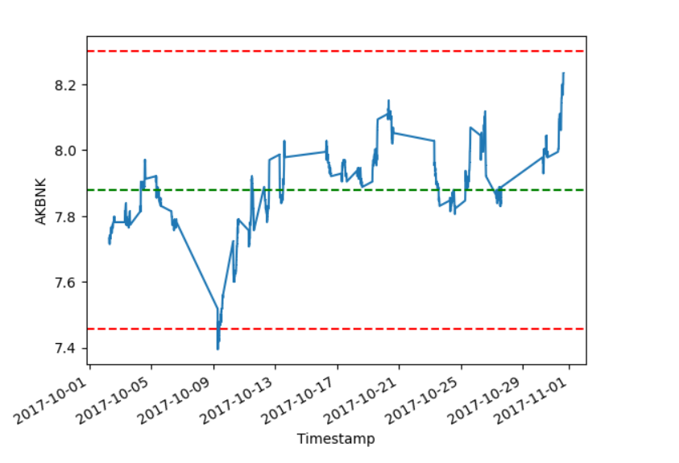

##### Google Trend Data

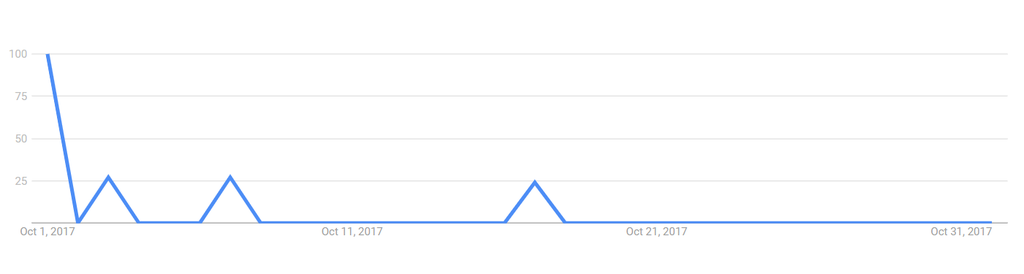

The agreement that happened on this date between Karsan and Akbank for a credit facility of 25 million euros might negatively impact Akbank's stock prices for several reasons. Firstly, extending a substantial credit facility to Karsan poses potential financial risks to Akbank if Karsan encounters challenges in repaying the loan, potentially affecting the bank's asset quality and exposing it to credit risk. Such risks could raise concerns among investors and contribute to a decrease in Akbank's stock prices.

Additionally, unfavorable terms in the agreement, such as unattractive interest rates or a repayment schedule that does not favor Akbank, could impact the bank's profitability. If the terms do not adequately account for the associated risks, this could further diminish investor confidence and lead to a decline in Akbank's stock prices.

Furthermore, if the market perceives the agreement with Karsan as an indication of increased credit risk for Akbank or a deviation from its standard risk management practices, this could undermine investor confidence and negatively impact the bank's stock prices.

In summary, the potential financial risks linked to the credit facility agreement with Karsan could erode investor sentiment and the perceived financial stability of Akbank, consequently contributing to a decrease in its stock prices.

### References

https://uzmanpara.milliyet.com.tr/

https://www.investing.com/

https://uzmanpara.milliyet.com.tr/kap-haberi/aksa-aksa-akrilik-kimya-sanayii-a-s--olagan-disi-fiyat-ve-miktar-hareketleri/1096108/

https://uzmanpara.milliyet.com.tr/raporlar-analizler/aksa-akrilik-kimya--geri-alim-programi-acikladi/1101133/

https://uzmanpara.milliyet.com.tr/raporlar-analizler/spk--sise-camin-borclanma-araci-ihracini-onayladi/1093558/

https://uzmanpara.milliyet.com.tr/raporlar-analizler/sisecamin-mersindeki-yeni-yatirimiyla-turkiyedeki-cam-ambalaj-kapasitesi-1-3-milyon-tona-yukselecek/1174128/